# Risk Factor Analysis

## Outcome Variable

**Outcome Variable:** ever_co

## Predictor Variables

**Intervention Variable:** impfloor

**Adjustment Set:**

- arm
- sex
- W_mage
- meducyrs
- feducyrs
- hhwealth_quart
- hfoodsec
- W_mhtcm
- W_nrooms
- W_nchldlt5
- W_parity
- impsan
- safeh20
- delta_W_mage
- delta_meducyrs
- delta_feducyrs
- delta_hhwealth_quart
- delta_hfoodsec
- delta_W_mhtcm
- delta_W_nrooms
- delta_W_nchldlt5
- delta_W_parity
- delta_impsan
- delta_safeh20

## Stratifying Variables

The analysis was stratified on these variable(s):

- agecat
- studyid
- country

## Data Summary

| agecat | studyid | country | impfloor | ever_co | n_cell | n |
| --- | --- | --- | --- | --- | --- | --- |
| 0-24 months | ki0047075b-MAL-ED | BANGLADESH | 1 | 0 | 189 | 242 |
| 0-24 months | ki0047075b-MAL-ED | BANGLADESH | 1 | 1 | 34 | 242 |
| 0-24 months | ki0047075b-MAL-ED | BANGLADESH | 0 | 0 | 14 | 242 |
| 0-24 months | ki0047075b-MAL-ED | BANGLADESH | 0 | 1 | 5 | 242 |
| 0-24 months | ki0047075b-MAL-ED | BRAZIL | 1 | 0 | 206 | 210 |
| 0-24 months | ki0047075b-MAL-ED | BRAZIL | 1 | 1 | 2 | 210 |
| 0-24 months | ki0047075b-MAL-ED | BRAZIL | 0 | 0 | 2 | 210 |
| 0-24 months | ki0047075b-MAL-ED | BRAZIL | 0 | 1 | 0 | 210 |
| 0-24 months | ki0047075b-MAL-ED | INDIA | 1 | 0 | 173 | 235 |
| 0-24 months | ki0047075b-MAL-ED | INDIA | 1 | 1 | 47 | 235 |
| 0-24 months | ki0047075b-MAL-ED | INDIA | 0 | 0 | 9 | 235 |
| 0-24 months | ki0047075b-MAL-ED | INDIA | 0 | 1 | 6 | 235 |
| 0-24 months | ki0047075b-MAL-ED | NEPAL | 1 | 0 | 94 | 229 |
| 0-24 months | ki0047075b-MAL-ED | NEPAL | 1 | 1 | 9 | 229 |
| 0-24 months | ki0047075b-MAL-ED | NEPAL | 0 | 0 | 116 | 229 |
| 0-24 months | ki0047075b-MAL-ED | NEPAL | 0 | 1 | 10 | 229 |
| 0-24 months | ki0047075b-MAL-ED | PERU | 1 | 0 | 55 | 272 |
| 0-24 months | ki0047075b-MAL-ED | PERU | 1 | 1 | 4 | 272 |
| 0-24 months | ki0047075b-MAL-ED | PERU | 0 | 0 | 206 | 272 |
| 0-24 months | ki0047075b-MAL-ED | PERU | 0 | 1 | 7 | 272 |
| 0-24 months | ki0047075b-MAL-ED | SOUTH AFRICA | 1 | 0 | 215 | 257 |
| 0-24 months | ki0047075b-MAL-ED | SOUTH AFRICA | 1 | 1 | 21 | 257 |
| 0-24 months | ki0047075b-MAL-ED | SOUTH AFRICA | 0 | 0 | 21 | 257 |
| 0-24 months | ki0047075b-MAL-ED | SOUTH AFRICA | 0 | 1 | 0 | 257 |
| 0-24 months | ki0047075b-MAL-ED | TANZANIA, UNITED REPUBLIC OF | 1 | 0 | 14 | 248 |
| 0-24 months | ki0047075b-MAL-ED | TANZANIA, UNITED REPUBLIC OF | 1 | 1 | 0 | 248 |
| 0-24 months | ki0047075b-MAL-ED | TANZANIA, UNITED REPUBLIC OF | 0 | 0 | 211 | 248 |
| 0-24 months | ki0047075b-MAL-ED | TANZANIA, UNITED REPUBLIC OF | 0 | 1 | 23 | 248 |
| 0-24 months | ki1000108-CMC-V-BCS-2002 | INDIA | 1 | 0 | 198 | 261 |
| 0-24 months | ki1000108-CMC-V-BCS-2002 | INDIA | 1 | 1 | 63 | 261 |

[output cut: 162 more lines]

The following strata were considered:

- agecat: 0-24 months, studyid: ki0047075b-MAL-ED, country: BANGLADESH
- agecat: 0-24 months, studyid: ki0047075b-MAL-ED, country: BRAZIL
- agecat: 0-24 months, studyid: ki0047075b-MAL-ED, country: INDIA
- agecat: 0-24 months, studyid: ki0047075b-MAL-ED, country: NEPAL
- agecat: 0-24 months, studyid: ki0047075b-MAL-ED, country: PERU
- agecat: 0-24 months, studyid: ki0047075b-MAL-ED, country: SOUTH AFRICA
- agecat: 0-24 months, studyid: ki0047075b-MAL-ED, country: TANZANIA, UNITED REPUBLIC OF
- agecat: 0-24 months, studyid: ki1000108-CMC-V-BCS-2002, country: INDIA
- agecat: 0-24 months, studyid: ki1000108-IRC, country: INDIA
- agecat: 0-24 months, studyid: ki1017093-NIH-Birth, country: BANGLADESH
- agecat: 0-24 months, studyid: ki1017093b-PROVIDE, country: BANGLADESH
- agecat: 0-24 months, studyid: ki1017093c-NIH-Crypto, country: BANGLADESH
- agecat: 0-24 months, studyid: ki1113344-GMS-Nepal, country: NEPAL
- agecat: 0-24 months, studyid: ki1114097-CONTENT, country: PERU
- agecat: 0-24 months, studyid: kiGH5241-JiVitA-3, country: BANGLADESH
- agecat: 0-24 months, studyid: kiGH5241-JiVitA-4, country: BANGLADESH
- agecat: 0-6 months, studyid: ki0047075b-MAL-ED, country: BANGLADESH
- agecat: 0-6 months, studyid: ki0047075b-MAL-ED, country: BRAZIL
- agecat: 0-6 months, studyid: ki0047075b-MAL-ED, country: INDIA
- agecat: 0-6 months, studyid: ki0047075b-MAL-ED, country: NEPAL
- agecat: 0-6 months, studyid: ki0047075b-MAL-ED, country: PERU
- agecat: 0-6 months, studyid: ki0047075b-MAL-ED, country: SOUTH AFRICA
- agecat: 0-6 months, studyid: ki0047075b-MAL-ED, country: TANZANIA, UNITED REPUBLIC OF
- agecat: 0-6 months, studyid: ki1000108-CMC-V-BCS-2002, country: INDIA
- agecat: 0-6 months, studyid: ki1000108-IRC, country: INDIA
- agecat: 0-6 months, studyid: ki1017093-NIH-Birth, country: BANGLADESH
- agecat: 0-6 months, studyid: ki1017093b-PROVIDE, country: BANGLADESH
- agecat: 0-6 months, studyid: ki1017093c-NIH-Crypto, country: BANGLADESH
- agecat: 0-6 months, studyid: ki1113344-GMS-Nepal, country: NEPAL
- agecat: 0-6 months, studyid: ki1114097-CONTENT, country: PERU
- agecat: 0-6 months, studyid: kiGH5241-JiVitA-3, country: BANGLADESH
- agecat: 0-6 months, studyid: kiGH5241-JiVitA-4, country: BANGLADESH
- agecat: 6-24 months, studyid: ki0047075b-MAL-ED, country: BANGLADESH
- agecat: 6-24 months, studyid: ki0047075b-MAL-ED, country: BRAZIL
- agecat: 6-24 months, studyid: ki0047075b-MAL-ED, country: INDIA
- agecat: 6-24 months, studyid: ki0047075b-MAL-ED, country: NEPAL
- agecat: 6-24 months, studyid: ki0047075b-MAL-ED, country: PERU
- agecat: 6-24 months, studyid: ki0047075b-MAL-ED, country: SOUTH AFRICA
- agecat: 6-24 months, studyid: ki0047075b-MAL-ED, country: TANZANIA, UNITED REPUBLIC OF
- agecat: 6-24 months, studyid: ki1000108-CMC-V-BCS-2002, country: INDIA
- agecat: 6-24 months, studyid: ki1000108-IRC, country: INDIA
- agecat: 6-24 months, studyid: ki1017093-NIH-Birth, country: BANGLADESH
- agecat: 6-24 months, studyid: ki1017093b-PROVIDE, country: BANGLADESH
- agecat: 6-24 months, studyid: ki1017093c-NIH-Crypto, country: BANGLADESH
- agecat: 6-24 months, studyid: ki1113344-GMS-Nepal, country: NEPAL
- agecat: 6-24 months, studyid: ki1114097-CONTENT, country: PERU
- agecat: 6-24 months, studyid: kiGH5241-JiVitA-3, country: BANGLADESH
- agecat: 6-24 months, studyid: kiGH5241-JiVitA-4, country: BANGLADESH

### Dropped Strata

Some strata were dropped due to rare outcomes:

- agecat: 0-24 months, studyid: ki0047075b-MAL-ED, country: BRAZIL
- agecat: 0-24 months, studyid: ki0047075b-MAL-ED, country: PERU
- agecat: 0-24 months, studyid: ki0047075b-MAL-ED, country: SOUTH AFRICA
- agecat: 0-24 months, studyid: ki0047075b-MAL-ED, country: TANZANIA, UNITED REPUBLIC OF
- agecat: 0-24 months, studyid: ki1000108-CMC-V-BCS-2002, country: INDIA
- agecat: 0-24 months, studyid: ki1000108-IRC, country: INDIA
- agecat: 0-24 months, studyid: ki1114097-CONTENT, country: PERU
- agecat: 0-6 months, studyid: ki0047075b-MAL-ED, country: BANGLADESH
- agecat: 0-6 months, studyid: ki0047075b-MAL-ED, country: BRAZIL
- agecat: 0-6 months, studyid: ki0047075b-MAL-ED, country: INDIA
- agecat: 0-6 months, studyid: ki0047075b-MAL-ED, country: NEPAL
- agecat: 0-6 months, studyid: ki0047075b-MAL-ED, country: PERU
- agecat: 0-6 months, studyid: ki0047075b-MAL-ED, country: SOUTH AFRICA
- agecat: 0-6 months, studyid: ki0047075b-MAL-ED, country: TANZANIA, UNITED REPUBLIC OF
- agecat: 0-6 months, studyid: ki1000108-CMC-V-BCS-2002, country: INDIA
- agecat: 0-6 months, studyid: ki1000108-IRC, country: INDIA
- agecat: 0-6 months, studyid: ki1017093c-NIH-Crypto, country: BANGLADESH
- agecat: 0-6 months, studyid: ki1113344-GMS-Nepal, country: NEPAL
- agecat: 0-6 months, studyid: ki1114097-CONTENT, country: PERU
- agecat: 6-24 months, studyid: ki0047075b-MAL-ED, country: BANGLADESH
- agecat: 6-24 months, studyid: ki0047075b-MAL-ED, country: BRAZIL
- agecat: 6-24 months, studyid: ki0047075b-MAL-ED, country: PERU
- agecat: 6-24 months, studyid: ki0047075b-MAL-ED, country: SOUTH AFRICA
- agecat: 6-24 months, studyid: ki0047075b-MAL-ED, country: TANZANIA, UNITED REPUBLIC OF
- agecat: 6-24 months, studyid: ki1000108-CMC-V-BCS-2002, country: INDIA
- agecat: 6-24 months, studyid: ki1000108-IRC, country: INDIA
- agecat: 6-24 months, studyid: ki1114097-CONTENT, country: PERU

## Methods Detail

We’re interested in the causal parameters $E[Y_a]$ for all values of $a \in \mathcal{A}$. These parameters represent the mean outcome if, possibly contrary to fact, we intervened to set all units to have $A=a$. Under the randomization and positivity assumptions, these are identified by the statistical parameters $\psi_a=E_W[E_{Y|A,W}(Y|A=a,W)]$. In addition, we’re interested in the mean of $Y$, $E[Y]$ under no intervention (the observed mean). We will estimate these parameters by using SuperLearner to fit the relevant likelihood factors – $E_{Y|A,W}(Y|A=a,W)$ and $p(A=a|W)$, and then updating our likelihood fit using a joint TMLE.

For unadjusted analyses ($W=\{\}$), initial likelihoods were estimated using Lrnr_glm to estimate the simple $E(Y|A)$ and Lrnr_mean to estimate $p(A)$. For adjusted analyses, a small library containing Lrnr_glmnet, Lrnr_xgboost, and Lrnr_mean was used.

Having estimated these parameters, we will then use the delta method to estimate relative risks and attributable risks relative to a prespecified baseline level of $A$.

# Results Detail

## Results Plots

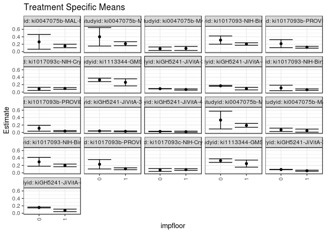

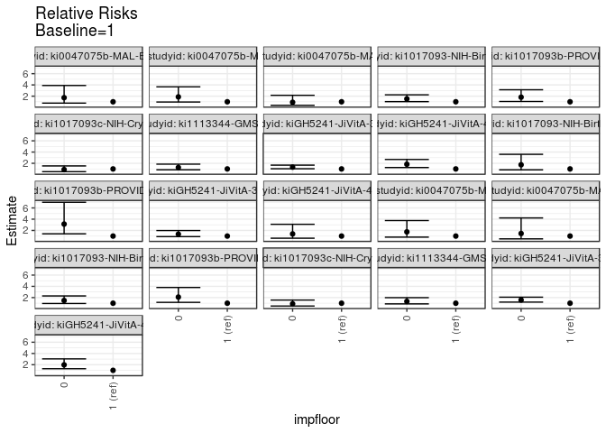

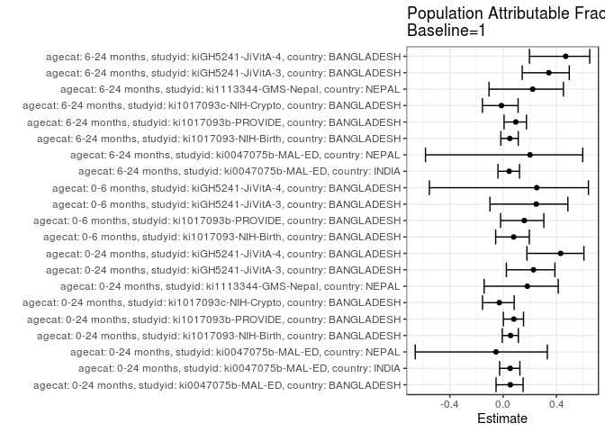

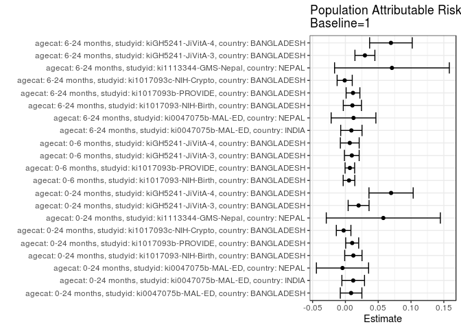

## Results Table

### Parameter: TSM

| agecat | studyid | country | intervention_level | baseline_level | estimate | ci_lower | ci_upper |
| --- | --- | --- | --- | --- | --- | --- | --- |
| 0-24 months | ki0047075b-MAL-ED | BANGLADESH | 1 | NA | 0.1524664 | 0.1051882 | 0.1997445 |
| 0-24 months | ki0047075b-MAL-ED | BANGLADESH | 0 | NA | 0.2631579 | 0.0647468 | 0.4615690 |
| 0-24 months | ki0047075b-MAL-ED | INDIA | 1 | NA | 0.2136364 | 0.1593598 | 0.2679129 |
| 0-24 months | ki0047075b-MAL-ED | INDIA | 0 | NA | 0.4000000 | 0.1515528 | 0.6484472 |
| 0-24 months | ki0047075b-MAL-ED | NEPAL | 1 | NA | 0.0873786 | 0.0327239 | 0.1420334 |
| 0-24 months | ki0047075b-MAL-ED | NEPAL | 0 | NA | 0.0793651 | 0.0320639 | 0.1266662 |
| 0-24 months | ki1017093-NIH-Birth | BANGLADESH | 1 | NA | 0.2052529 | 0.1714566 | 0.2390492 |
| 0-24 months | ki1017093-NIH-Birth | BANGLADESH | 0 | NA | 0.3112294 | 0.2005682 | 0.4218905 |
| 0-24 months | ki1017093b-PROVIDE | BANGLADESH | 1 | NA | 0.1182253 | 0.0932063 | 0.1432442 |
| 0-24 months | ki1017093b-PROVIDE | BANGLADESH | 0 | NA | 0.2147702 | 0.1062985 | 0.3232419 |
| 0-24 months | ki1017093c-NIH-Crypto | BANGLADESH | 1 | NA | 0.0963724 | 0.0723092 | 0.1204356 |
| 0-24 months | ki1017093c-NIH-Crypto | BANGLADESH | 0 | NA | 0.0854416 | 0.0436835 | 0.1271997 |
| 0-24 months | ki1113344-GMS-Nepal | NEPAL | 1 | NA | 0.2607700 | 0.1658193 | 0.3557206 |
| 0-24 months | ki1113344-GMS-Nepal | NEPAL | 0 | NA | 0.3265735 | 0.2798693 | 0.3732776 |
| 0-24 months | kiGH5241-JiVitA-3 | BANGLADESH | 1 | NA | 0.0683034 | 0.0519393 | 0.0846676 |
| 0-24 months | kiGH5241-JiVitA-3 | BANGLADESH | 0 | NA | 0.0898018 | 0.0858081 | 0.0937955 |
| 0-24 months | kiGH5241-JiVitA-4 | BANGLADESH | 1 | NA | 0.0918372 | 0.0569015 | 0.1267729 |
| 0-24 months | kiGH5241-JiVitA-4 | BANGLADESH | 0 | NA | 0.1678970 | 0.1559846 | 0.1798094 |
| 0-6 months | ki1017093-NIH-Birth | BANGLADESH | 1 | NA | 0.0639854 | 0.0434602 | 0.0845106 |
| 0-6 months | ki1017093-NIH-Birth | BANGLADESH | 0 | NA | 0.1111111 | 0.0384611 | 0.1837611 |
| 0-6 months | ki1017093b-PROVIDE | BANGLADESH | 1 | NA | 0.0360502 | 0.0215748 | 0.0505255 |
| 0-6 months | ki1017093b-PROVIDE | BANGLADESH | 0 | NA | 0.1129032 | 0.0340714 | 0.1917350 |
| 0-6 months | kiGH5241-JiVitA-3 | BANGLADESH | 1 | NA | 0.0295584 | 0.0181161 | 0.0410007 |
| 0-6 months | kiGH5241-JiVitA-3 | BANGLADESH | 0 | NA | 0.0395240 | 0.0369027 | 0.0421453 |
| 0-6 months | kiGH5241-JiVitA-4 | BANGLADESH | 1 | NA | 0.0197200 | 0.0043426 | 0.0350973 |
| 0-6 months | kiGH5241-JiVitA-4 | BANGLADESH | 0 | NA | 0.0272856 | 0.0216343 | 0.0329369 |
| 6-24 months | ki0047075b-MAL-ED | INDIA | 1 | NA | 0.1909091 | 0.1388646 | 0.2429536 |
| 6-24 months | ki0047075b-MAL-ED | INDIA | 0 | NA | 0.3333333 | 0.0942649 | 0.5724018 |
| 6-24 months | ki0047075b-MAL-ED | NEPAL | 1 | NA | 0.0490196 | 0.0070270 | 0.0910123 |
| 6-24 months | ki0047075b-MAL-ED | NEPAL | 0 | NA | 0.0714286 | 0.0263613 | 0.1164958 |
| 6-24 months | ki1017093-NIH-Birth | BANGLADESH | 1 | NA | 0.2008463 | 0.1648437 | 0.2368489 |
| 6-24 months | ki1017093-NIH-Birth | BANGLADESH | 0 | NA | 0.2966712 | 0.1774630 | 0.4158795 |
| 6-24 months | ki1017093b-PROVIDE | BANGLADESH | 1 | NA | 0.1105480 | 0.0847565 | 0.1363395 |
| 6-24 months | ki1017093b-PROVIDE | BANGLADESH | 0 | NA | 0.2313269 | 0.1044545 | 0.3581994 |
| 6-24 months | ki1017093c-NIH-Crypto | BANGLADESH | 1 | NA | 0.0873818 | 0.0637760 | 0.1109876 |
| 6-24 months | ki1017093c-NIH-Crypto | BANGLADESH | 0 | NA | 0.0775296 | 0.0389443 | 0.1161150 |
| 6-24 months | ki1113344-GMS-Nepal | NEPAL | 1 | NA | 0.2486969 | 0.1535775 | 0.3438163 |
| 6-24 months | ki1113344-GMS-Nepal | NEPAL | 0 | NA | 0.3289559 | 0.2816215 | 0.3762903 |
| 6-24 months | kiGH5241-JiVitA-3 | BANGLADESH | 1 | NA | 0.0569166 | 0.0415041 | 0.0723291 |
| 6-24 months | kiGH5241-JiVitA-3 | BANGLADESH | 0 | NA | 0.0896070 | 0.0847245 | 0.0944895 |
| 6-24 months | kiGH5241-JiVitA-4 | BANGLADESH | 1 | NA | 0.0783389 | 0.0450313 | 0.1116465 |
| 6-24 months | kiGH5241-JiVitA-4 | BANGLADESH | 0 | NA | 0.1550741 | 0.1435742 | 0.1665740 |

### Parameter: E(Y)

| agecat | studyid | country | intervention_level | baseline_level | estimate | ci_lower | ci_upper |
| --- | --- | --- | --- | --- | --- | --- | --- |
| 0-24 months | ki0047075b-MAL-ED | BANGLADESH | NA | NA | 0.1611570 | 0.1147371 | 0.2075770 |
| 0-24 months | ki0047075b-MAL-ED | INDIA | NA | NA | 0.2255319 | 0.1719836 | 0.2790802 |
| 0-24 months | ki0047075b-MAL-ED | NEPAL | NA | NA | 0.0829694 | 0.0471654 | 0.1187734 |
| 0-24 months | ki1017093-NIH-Birth | BANGLADESH | NA | NA | 0.2173913 | 0.1849240 | 0.2498586 |
| 0-24 months | ki1017093b-PROVIDE | BANGLADESH | NA | NA | 0.1285714 | 0.1037574 | 0.1533855 |
| 0-24 months | ki1017093c-NIH-Crypto | BANGLADESH | NA | NA | 0.0936675 | 0.0729118 | 0.1144233 |
| 0-24 months | ki1113344-GMS-Nepal | NEPAL | NA | NA | 0.3185654 | 0.2765770 | 0.3605538 |
| 0-24 months | kiGH5241-JiVitA-3 | BANGLADESH | NA | NA | 0.0884280 | 0.0845825 | 0.0922736 |
| 0-24 months | kiGH5241-JiVitA-4 | BANGLADESH | NA | NA | 0.1614747 | 0.1501435 | 0.1728058 |
| 0-6 months | ki1017093-NIH-Birth | BANGLADESH | NA | NA | 0.0694669 | 0.0494218 | 0.0895120 |
| 0-6 months | ki1017093b-PROVIDE | BANGLADESH | NA | NA | 0.0428571 | 0.0278427 | 0.0578716 |
| 0-6 months | kiGH5241-JiVitA-3 | BANGLADESH | NA | NA | 0.0393256 | 0.0368449 | 0.0418063 |
| 0-6 months | kiGH5241-JiVitA-4 | BANGLADESH | NA | NA | 0.0263831 | 0.0210411 | 0.0317252 |
| 6-24 months | ki0047075b-MAL-ED | INDIA | NA | NA | 0.2000000 | 0.1487493 | 0.2512507 |
| 6-24 months | ki0047075b-MAL-ED | NEPAL | NA | NA | 0.0614035 | 0.0301736 | 0.0926335 |
| 6-24 months | ki1017093-NIH-Birth | BANGLADESH | NA | NA | 0.2115028 | 0.1769952 | 0.2460104 |
| 6-24 months | ki1017093b-PROVIDE | BANGLADESH | NA | NA | 0.1221498 | 0.0962275 | 0.1480722 |
| 6-24 months | ki1017093c-NIH-Crypto | BANGLADESH | NA | NA | 0.0863014 | 0.0659171 | 0.1066856 |
| 6-24 months | ki1113344-GMS-Nepal | NEPAL | NA | NA | 0.3196544 | 0.2771306 | 0.3621782 |
| 6-24 months | kiGH5241-JiVitA-3 | BANGLADESH | NA | NA | 0.0866539 | 0.0820272 | 0.0912806 |
| 6-24 months | kiGH5241-JiVitA-4 | BANGLADESH | NA | NA | 0.1477587 | 0.1371623 | 0.1583552 |

### Parameter: RR

| agecat | studyid | country | intervention_level | baseline_level | estimate | ci_lower | ci_upper |
| --- | --- | --- | --- | --- | --- | --- | --- |
| 0-24 months | ki0047075b-MAL-ED | BANGLADESH | 1 | 1 | 1.0000000 | 1.0000000 | 1.000000 |
| 0-24 months | ki0047075b-MAL-ED | BANGLADESH | 0 | 1 | 1.7260062 | 0.7638160 | 3.900281 |
| 0-24 months | ki0047075b-MAL-ED | INDIA | 1 | 1 | 1.0000000 | 1.0000000 | 1.000000 |
| 0-24 months | ki0047075b-MAL-ED | INDIA | 0 | 1 | 1.8723404 | 0.9570686 | 3.662913 |
| 0-24 months | ki0047075b-MAL-ED | NEPAL | 1 | 1 | 1.0000000 | 1.0000000 | 1.000000 |
| 0-24 months | ki0047075b-MAL-ED | NEPAL | 0 | 1 | 0.9082892 | 0.3828292 | 2.154980 |
| 0-24 months | ki1017093-NIH-Birth | BANGLADESH | 1 | 1 | 1.0000000 | 1.0000000 | 1.000000 |
| 0-24 months | ki1017093-NIH-Birth | BANGLADESH | 0 | 1 | 1.5163212 | 1.0257353 | 2.241543 |
| 0-24 months | ki1017093b-PROVIDE | BANGLADESH | 1 | 1 | 1.0000000 | 1.0000000 | 1.000000 |
| 0-24 months | ki1017093b-PROVIDE | BANGLADESH | 0 | 1 | 1.8166182 | 1.0517768 | 3.137644 |
| 0-24 months | ki1017093c-NIH-Crypto | BANGLADESH | 1 | 1 | 1.0000000 | 1.0000000 | 1.000000 |
| 0-24 months | ki1017093c-NIH-Crypto | BANGLADESH | 0 | 1 | 0.8865776 | 0.5122319 | 1.534500 |
| 0-24 months | ki1113344-GMS-Nepal | NEPAL | 1 | 1 | 1.0000000 | 1.0000000 | 1.000000 |
| 0-24 months | ki1113344-GMS-Nepal | NEPAL | 0 | 1 | 1.2523430 | 0.8481105 | 1.849244 |
| 0-24 months | kiGH5241-JiVitA-3 | BANGLADESH | 1 | 1 | 1.0000000 | 1.0000000 | 1.000000 |
| 0-24 months | kiGH5241-JiVitA-3 | BANGLADESH | 0 | 1 | 1.3147479 | 1.0327546 | 1.673739 |
| 0-24 months | kiGH5241-JiVitA-4 | BANGLADESH | 1 | 1 | 1.0000000 | 1.0000000 | 1.000000 |
| 0-24 months | kiGH5241-JiVitA-4 | BANGLADESH | 0 | 1 | 1.8282025 | 1.2456113 | 2.683280 |
| 0-6 months | ki1017093-NIH-Birth | BANGLADESH | 1 | 1 | 1.0000000 | 1.0000000 | 1.000000 |
| 0-6 months | ki1017093-NIH-Birth | BANGLADESH | 0 | 1 | 1.7365079 | 0.8382638 | 3.597268 |
| 0-6 months | ki1017093b-PROVIDE | BANGLADESH | 1 | 1 | 1.0000000 | 1.0000000 | 1.000000 |
| 0-6 months | ki1017093b-PROVIDE | BANGLADESH | 0 | 1 | 3.1318373 | 1.3995795 | 7.008108 |
| 0-6 months | kiGH5241-JiVitA-3 | BANGLADESH | 1 | 1 | 1.0000000 | 1.0000000 | 1.000000 |
| 0-6 months | kiGH5241-JiVitA-3 | BANGLADESH | 0 | 1 | 1.3371474 | 0.9027905 | 1.980485 |
| 0-6 months | kiGH5241-JiVitA-4 | BANGLADESH | 1 | 1 | 1.0000000 | 1.0000000 | 1.000000 |
| 0-6 months | kiGH5241-JiVitA-4 | BANGLADESH | 0 | 1 | 1.3836535 | 0.6189096 | 3.093338 |
| 6-24 months | ki0047075b-MAL-ED | INDIA | 1 | 1 | 1.0000000 | 1.0000000 | 1.000000 |
| 6-24 months | ki0047075b-MAL-ED | INDIA | 0 | 1 | 1.7460317 | 0.8106464 | 3.760736 |
| 6-24 months | ki0047075b-MAL-ED | NEPAL | 1 | 1 | 1.0000000 | 1.0000000 | 1.000000 |
| 6-24 months | ki0047075b-MAL-ED | NEPAL | 0 | 1 | 1.4571428 | 0.5028581 | 4.222395 |
| 6-24 months | ki1017093-NIH-Birth | BANGLADESH | 1 | 1 | 1.0000000 | 1.0000000 | 1.000000 |
| 6-24 months | ki1017093-NIH-Birth | BANGLADESH | 0 | 1 | 1.4771058 | 0.9512693 | 2.293611 |
| 6-24 months | ki1017093b-PROVIDE | BANGLADESH | 1 | 1 | 1.0000000 | 1.0000000 | 1.000000 |
| 6-24 months | ki1017093b-PROVIDE | BANGLADESH | 0 | 1 | 2.0925466 | 1.1541581 | 3.793892 |
| 6-24 months | ki1017093c-NIH-Crypto | BANGLADESH | 1 | 1 | 1.0000000 | 1.0000000 | 1.000000 |
| 6-24 months | ki1017093c-NIH-Crypto | BANGLADESH | 0 | 1 | 0.8872515 | 0.5040519 | 1.561774 |
| 6-24 months | ki1113344-GMS-Nepal | NEPAL | 1 | 1 | 1.0000000 | 1.0000000 | 1.000000 |
| 6-24 months | ki1113344-GMS-Nepal | NEPAL | 0 | 1 | 1.3227180 | 0.8799725 | 1.988225 |
| 6-24 months | kiGH5241-JiVitA-3 | BANGLADESH | 1 | 1 | 1.0000000 | 1.0000000 | 1.000000 |
| 6-24 months | kiGH5241-JiVitA-3 | BANGLADESH | 0 | 1 | 1.5743570 | 1.1948170 | 2.074460 |
| 6-24 months | kiGH5241-JiVitA-4 | BANGLADESH | 1 | 1 | 1.0000000 | 1.0000000 | 1.000000 |
| 6-24 months | kiGH5241-JiVitA-4 | BANGLADESH | 0 | 1 | 1.9795283 | 1.2887762 | 3.040506 |

### Parameter: PAR

| agecat | studyid | country | intervention_level | baseline_level | estimate | ci_lower | ci_upper |
| --- | --- | --- | --- | --- | --- | --- | --- |
| 0-24 months | ki0047075b-MAL-ED | BANGLADESH | 1 | NA | 0.0086907 | -0.0077585 | 0.0251398 |
| 0-24 months | ki0047075b-MAL-ED | INDIA | 1 | NA | 0.0118956 | -0.0053544 | 0.0291455 |
| 0-24 months | ki0047075b-MAL-ED | NEPAL | 1 | NA | -0.0044092 | -0.0441829 | 0.0353645 |
| 0-24 months | ki1017093-NIH-Birth | BANGLADESH | 1 | NA | 0.0121384 | -0.0010458 | 0.0253225 |
| 0-24 months | ki1017093b-PROVIDE | BANGLADESH | 1 | NA | 0.0103462 | 0.0004550 | 0.0202373 |
| 0-24 months | ki1017093c-NIH-Crypto | BANGLADESH | 1 | NA | -0.0027049 | -0.0138305 | 0.0084208 |
| 0-24 months | ki1113344-GMS-Nepal | NEPAL | 1 | NA | 0.0577954 | -0.0291425 | 0.1447334 |
| 0-24 months | kiGH5241-JiVitA-3 | BANGLADESH | 1 | NA | 0.0201246 | 0.0041962 | 0.0360530 |
| 0-24 months | kiGH5241-JiVitA-4 | BANGLADESH | 1 | NA | 0.0696375 | 0.0359425 | 0.1033324 |
| 0-6 months | ki1017093-NIH-Birth | BANGLADESH | 1 | NA | 0.0054815 | -0.0033801 | 0.0143431 |
| 0-6 months | ki1017093b-PROVIDE | BANGLADESH | 1 | NA | 0.0068070 | -0.0004742 | 0.0140882 |
| 0-6 months | kiGH5241-JiVitA-3 | BANGLADESH | 1 | NA | 0.0097672 | -0.0014568 | 0.0209912 |
| 0-6 months | kiGH5241-JiVitA-4 | BANGLADESH | 1 | NA | 0.0066632 | -0.0076754 | 0.0210017 |
| 6-24 months | ki0047075b-MAL-ED | INDIA | 1 | NA | 0.0090909 | -0.0071508 | 0.0253326 |
| 6-24 months | ki0047075b-MAL-ED | NEPAL | 1 | NA | 0.0123839 | -0.0216885 | 0.0464563 |
| 6-24 months | ki1017093-NIH-Birth | BANGLADESH | 1 | NA | 0.0106565 | -0.0032043 | 0.0245173 |
| 6-24 months | ki1017093b-PROVIDE | BANGLADESH | 1 | NA | 0.0116018 | 0.0011236 | 0.0220800 |
| 6-24 months | ki1017093c-NIH-Crypto | BANGLADESH | 1 | NA | -0.0010804 | -0.0126027 | 0.0104418 |
| 6-24 months | ki1113344-GMS-Nepal | NEPAL | 1 | NA | 0.0709575 | -0.0165039 | 0.1584189 |
| 6-24 months | kiGH5241-JiVitA-3 | BANGLADESH | 1 | NA | 0.0297373 | 0.0145460 | 0.0449286 |
| 6-24 months | kiGH5241-JiVitA-4 | BANGLADESH | 1 | NA | 0.0694198 | 0.0369144 | 0.1019252 |

### Parameter: PAF

| agecat | studyid | country | intervention_level | baseline_level | estimate | ci_lower | ci_upper |
| --- | --- | --- | --- | --- | --- | --- | --- |
| 0-24 months | ki0047075b-MAL-ED | BANGLADESH | 1 | NA | 0.0539266 | -0.0530109 | 0.1500043 |
| 0-24 months | ki0047075b-MAL-ED | INDIA | 1 | NA | 0.0527444 | -0.0264141 | 0.1257982 |
| 0-24 months | ki0047075b-MAL-ED | NEPAL | 1 | NA | -0.0531426 | -0.6595466 | 0.3316794 |
| 0-24 months | ki1017093-NIH-Birth | BANGLADESH | 1 | NA | 0.0558366 | -0.0065207 | 0.1143306 |
| 0-24 months | ki1017093b-PROVIDE | BANGLADESH | 1 | NA | 0.0804701 | 0.0015488 | 0.1531532 |
| 0-24 months | ki1017093c-NIH-Crypto | BANGLADESH | 1 | NA | -0.0288772 | -0.1545965 | 0.0831530 |
| 0-24 months | ki1113344-GMS-Nepal | NEPAL | 1 | NA | 0.1814240 | -0.1425440 | 0.4135310 |
| 0-24 months | kiGH5241-JiVitA-3 | BANGLADESH | 1 | NA | 0.2275816 | 0.0244474 | 0.3884183 |
| 0-24 months | kiGH5241-JiVitA-4 | BANGLADESH | 1 | NA | 0.4312593 | 0.1784708 | 0.6062636 |
| 0-6 months | ki1017093-NIH-Birth | BANGLADESH | 1 | NA | 0.0789082 | -0.0558885 | 0.1964965 |
| 0-6 months | ki1017093b-PROVIDE | BANGLADESH | 1 | NA | 0.1588297 | -0.0189113 | 0.3055651 |
| 0-6 months | kiGH5241-JiVitA-3 | BANGLADESH | 1 | NA | 0.2483674 | -0.0989286 | 0.4859070 |
| 0-6 months | kiGH5241-JiVitA-4 | BANGLADESH | 1 | NA | 0.2525540 | -0.5531126 | 0.6402865 |
| 6-24 months | ki0047075b-MAL-ED | INDIA | 1 | NA | 0.0454545 | -0.0388318 | 0.1229023 |
| 6-24 months | ki0047075b-MAL-ED | NEPAL | 1 | NA | 0.2016807 | -0.5826684 | 0.5973169 |
| 6-24 months | ki1017093-NIH-Birth | BANGLADESH | 1 | NA | 0.0503846 | -0.0172180 | 0.1134945 |
| 6-24 months | ki1017093b-PROVIDE | BANGLADESH | 1 | NA | 0.0949801 | 0.0071758 | 0.1750191 |
| 6-24 months | ki1017093c-NIH-Crypto | BANGLADESH | 1 | NA | -0.0125191 | -0.1552064 | 0.1125439 |
| 6-24 months | ki1113344-GMS-Nepal | NEPAL | 1 | NA | 0.2219820 | -0.1058662 | 0.4526353 |
| 6-24 months | kiGH5241-JiVitA-3 | BANGLADESH | 1 | NA | 0.3431736 | 0.1434832 | 0.4963076 |
| 6-24 months | kiGH5241-JiVitA-4 | BANGLADESH | 1 | NA | 0.4698187 | 0.1976618 | 0.6496588 |